# Supplementary Methods

wucy

Tuesday, August 30, 2016

# Fig.1 Effects of IL-17 on body weight during HFD feeding

```
We use the other drawing software.
```

# Fig.2 IL-17 significantly influences HFD induced disorders

```
We use the other drawing software.
```

# Fig.3 Metagenomic analysis of mice feces. Before HFD feeding feces were 827 harvested (0w)

```
We use the other drawing software.
```

This beginning workspace contains: * `profiling_species_absolute`: Species abundance * `profiling_species`: Relative abundance on species * `profile_phylum`: Relative abundance on phylum * `profile_genus`: Relative abundance on genus

```r
###Load the necessary data.
load("data/data.RData")
###Row: the name of the species; Col: the name of the sample.
head(profiling_species_absolute)
```

```
##                                     KO_0w       KO_14w       KO_27w
## Abiotrophia_defectiva        0.000000e+00 4.029400e-07 0.000000e+00
## Achromobacter_arsenitoxydans 0.000000e+00 0.000000e+00 7.167341e-08
## Achromobacter_piechaudii     0.000000e+00 0.000000e+00 0.000000e+00
## Achromobacter_xylosoxidans   0.000000e+00 0.000000e+00 0.000000e+00
## Acidaminococcus_sp_D21       5.125971e-05 1.031691e-04 6.416895e-04
## Acidovorax_ebreus            2.658876e-07 3.512217e-07 0.000000e+00
##                                     KO_HY       KO_gut      NOR_14w
## Abiotrophia_defectiva        0.000000e+00 0.000000e+00 2.063792e-06
## Achromobacter_arsenitoxydans 0.000000e+00 2.552354e-09 0.000000e+00
## Achromobacter_piechaudii     0.000000e+00 0.000000e+00 2.727081e-08
## Achromobacter_xylosoxidans   1.228014e-06 0.000000e+00 0.000000e+00
## Acidaminococcus_sp_D21       2.865883e-04 7.860815e-04 8.967465e-05
## Acidovorax_ebreus            3.390164e-07 0.000000e+00 0.000000e+00
##                                   NOR_27w       NOR_HY      NOR_gut
## Abiotrophia_defectiva        7.756585e-06 0.000000e+00 6.653475e-07
## Achromobacter_arsenitoxydans 0.000000e+00 0.000000e+00 1.274304e-09
## Achromobacter_piechaudii     0.000000e+00 1.469448e-07 0.000000e+00
## Achromobacter_xylosoxidans   0.000000e+00 3.122997e-07 0.000000e+00
## Acidaminococcus_sp_D21       3.089296e-04 1.399393e-04 1.060360e-04
## Acidovorax_ebreus            3.160995e-06 6.427599e-07 0.000000e+00
##                                     WT_0w       WT_14w       WT_27w
## Abiotrophia_defectiva        0.000000e+00 0.000000e+00 0.0000000000
## Achromobacter_arsenitoxydans 0.000000e+00 0.000000e+00 0.0000000000
## Achromobacter_piechaudii     0.000000e+00 1.125050e-08 0.0000000000
## Achromobacter_xylosoxidans   1.567190e-07 0.000000e+00 0.0000000000
## Acidaminococcus_sp_D21       9.035575e-05 1.490449e-04 0.0003578952
## Acidovorax_ebreus            1.317081e-07 0.000000e+00 0.0000000000
##                                     WT_HY       WT_gut
## Abiotrophia_defectiva        1.044146e-07 3.129243e-07
## Achromobacter_arsenitoxydans 0.000000e+00 0.000000e+00
## Achromobacter_piechaudii     1.462565e-07 0.000000e+00
## Achromobacter_xylosoxidans   3.107462e-07 0.000000e+00
## Acidaminococcus_sp_D21       4.150418e-04 6.168979e-04
## Acidovorax_ebreus            0.000000e+00 5.268325e-07
```

```r
###Row: the name of the species; Col: the name of the sample.
head(profiling_species)
```

```
##                                     KO_0w       KO_14w       KO_27w
## Abiotrophia_defectiva        0.000000e+00 2.342851e-06 0.000000e+00
## Achromobacter_arsenitoxydans 0.000000e+00 0.000000e+00 9.832326e-07
## Achromobacter_piechaudii     0.000000e+00 0.000000e+00 0.000000e+00
## Achromobacter_xylosoxidans   0.000000e+00 0.000000e+00 0.000000e+00
## Acidaminococcus_sp_D21       1.770802e-04 5.998652e-04 8.802847e-03
## Acidovorax_ebreus            9.185273e-07 2.042140e-06 0.000000e+00
##                                     KO_HY       KO_gut      NOR_14w
## Abiotrophia_defectiva        0.000000e+00 0.000000e+00 1.788330e-05
## Achromobacter_arsenitoxydans 0.000000e+00 8.905524e-09 0.000000e+00
## Achromobacter_piechaudii     0.000000e+00 0.000000e+00 2.363087e-07
## Achromobacter_xylosoxidans   1.447336e-05 0.000000e+00 0.000000e+00
## Acidaminococcus_sp_D21       3.377728e-03 2.742749e-03 7.770544e-04
## Acidovorax_ebreus            3.995646e-06 0.000000e+00 0.000000e+00
##                                   NOR_27w       NOR_HY      NOR_gut
## Abiotrophia_defectiva        4.247967e-05 0.000000e+00 2.943623e-06
## Achromobacter_arsenitoxydans 0.000000e+00 0.000000e+00 5.637761e-09
## Achromobacter_piechaudii     0.000000e+00 1.605245e-06 0.000000e+00
## Achromobacter_xylosoxidans   0.000000e+00 3.411604e-06 0.000000e+00
## Acidaminococcus_sp_D21       1.691882e-03 1.528716e-03 4.691235e-04
## Acidovorax_ebreus            1.731149e-05 7.021596e-06 0.000000e+00
##                                     WT_0w       WT_14w      WT_27w
## Abiotrophia_defectiva        0.000000e+00 0.000000e+00 0.000000000
## Achromobacter_arsenitoxydans 0.000000e+00 0.000000e+00 0.000000000
## Achromobacter_piechaudii     0.000000e+00 5.117212e-08 0.000000000
## Achromobacter_xylosoxidans   2.098084e-06 0.000000e+00 0.000000000
## Acidaminococcus_sp_D21       1.209643e-03 6.779205e-04 0.001584588
## Acidovorax_ebreus            1.763250e-06 0.000000e+00 0.000000000
##                                     WT_HY       WT_gut
## Abiotrophia_defectiva        2.066513e-06 1.080890e-06
## Achromobacter_arsenitoxydans 0.000000e+00 0.000000e+00
## Achromobacter_piechaudii     2.894624e-06 0.000000e+00
## Achromobacter_xylosoxidans   6.150109e-06 0.000000e+00
## Acidaminococcus_sp_D21       8.214267e-03 2.130862e-03
## Acidovorax_ebreus            0.000000e+00 1.819762e-06
```

```r
###Row: the name of the species; Col: the name of the sample.
head(profile_phylum)
```

```
##                            KO_0w      KO_14w       KO_27w        KO_HY
## Actinobacteria      2.850798e-04 0.003201004 9.263488e-03 3.306621e-03
## Bacteroidetes       9.126590e-01 0.605842139 5.822601e-01 7.448578e-01
## Chlamydiae          2.214223e-02 0.026623401 1.895889e-03 1.235395e-02
## Cyanobacteria       0.000000e+00 0.000000000 0.000000e+00 1.060477e-08
## Deinococcus_Thermus 8.933201e-05 0.000000000 2.913088e-05 1.827371e-04
## Firmicutes          4.830481e-02 0.351750918 3.715614e-01 1.964305e-01
##                           KO_gut     NOR_14w      NOR_27w       NOR_HY
## Actinobacteria      2.137645e-03 0.002229545 1.512560e-03 0.0022502204
## Bacteroidetes       8.883311e-01 0.582888773 8.163706e-01 0.7723517779
## Chlamydiae          1.590616e-03 0.023969374 9.026272e-03 0.0188726290
## Cyanobacteria       0.000000e+00 0.000000000 8.188075e-07 0.0000000000
## Deinococcus_Thermus 1.185479e-05 0.000000000 1.191368e-04 0.0002299175
## Firmicutes          9.007844e-02 0.305191799 1.579409e-01 0.1873139410
##                          NOR_gut        WT_0w       WT_14w       WT_27w
## Actinobacteria      1.092190e-03 6.575788e-04 1.534936e-03 1.181421e-03
## Bacteroidetes       9.504896e-01 5.544755e-01 4.417242e-01 8.547427e-01
## Chlamydiae          3.455833e-03 7.463891e-05 9.528044e-06 2.136664e-02
## Cyanobacteria       0.000000e+00 2.214137e-04 0.000000e+00 0.000000e+00
## Deinococcus_Thermus 9.491869e-06 4.013971e-04 1.931732e-06 1.272076e-05
## Firmicutes          3.772108e-02 2.817809e-01 2.234119e-01 1.014096e-01
##                            WT_HY       WT_gut
## Actinobacteria      0.0059657994 2.438315e-03
## Bacteroidetes       0.5202565674 7.983211e-01
## Chlamydiae          0.0224731323 4.260305e-02
## Cyanobacteria       0.0000000000 0.000000e+00
## Deinococcus_Thermus 0.0003151378 3.998072e-06
## Firmicutes          0.4114112973 1.010416e-01
```

```r
###Row: the name of the species; Col: the name of the sample.
head(profile_genus)
```

```
##                        KO_0w       KO_14w       KO_27w        KO_HY
## Abiotrophia     0.000000e+00 2.342851e-06 0.000000e+00 0.000000e+00
## Achromobacter   0.000000e+00 0.000000e+00 9.832326e-07 1.447336e-05
## Acidaminococcus 1.770802e-04 5.998652e-04 8.802847e-03 3.377728e-03
## Acidovorax      1.672100e-06 2.676310e-06 6.675901e-06 1.354167e-05
## Acinetobacter   7.195150e-05 9.248156e-05 7.570055e-03 2.686759e-02
## Actinobacillus  5.868716e-06 0.000000e+00 5.239062e-04 1.043522e-06
##                       KO_gut      NOR_14w      NOR_27w       NOR_HY
## Abiotrophia     0.000000e+00 1.788330e-05 4.247967e-05 0.000000e+00
## Achromobacter   8.905524e-09 2.363087e-07 0.000000e+00 5.016849e-06
## Acidaminococcus 2.742749e-03 7.770544e-04 1.691882e-03 1.528716e-03
## Acidovorax      3.805571e-06 0.000000e+00 1.731149e-05 1.048402e-05
## Acinetobacter   1.440618e-05 5.943539e-05 6.179381e-04 8.103789e-03
## Actinobacillus  0.000000e+00 0.000000e+00 1.409003e-06 5.545902e-06
##                      NOR_gut        WT_0w       WT_14w       WT_27w
## Abiotrophia     2.943623e-06 0.000000e+00 0.000000e+00 0.000000e+00
## Achromobacter   5.637761e-09 2.098084e-06 5.117212e-08 0.000000e+00
## Acidaminococcus 4.691235e-04 1.209643e-03 6.779205e-04 1.584588e-03
## Acidovorax      1.930168e-06 5.920653e-06 0.000000e+00 5.794864e-06
## Acinetobacter   1.397949e-05 3.899986e-05 4.368385e-05 1.525598e-05
## Actinobacillus  0.000000e+00 0.000000e+00 0.000000e+00 1.336600e-06
##                        WT_HY       WT_gut
## Abiotrophia     2.066513e-06 1.080890e-06
## Achromobacter   9.044733e-06 0.000000e+00
## Acidaminococcus 8.214267e-03 2.130862e-03
## Acidovorax      0.000000e+00 1.819762e-06
## Acinetobacter   1.294002e-02 1.457907e-05
## Actinobacillus  0.000000e+00 0.000000e+00
```

```r
###Load the necessary function.
source("data/functions.R")
#The total of 14 color template
palette <- c("red", "gray", "cornflowerblue", "chartreuse3", "yellow", "honeydew4",
            "indianred4", "khaki", "lightseagreen", "lightslateblue", "magenta",
            "orange2", "purple", "black")
###Obtain color
colfunc <- colorRampPalette(palette, interpolate = "spline", space = "Lab")
```

## Fig3-A

- `a`: species number in the feces from WT or Il-17a-/- mice before HFD feeding.
- `b`: Shannon Index indicated the composition difference between these two groups.
- `c`: Taxon-based analysis at genus level among the two groups

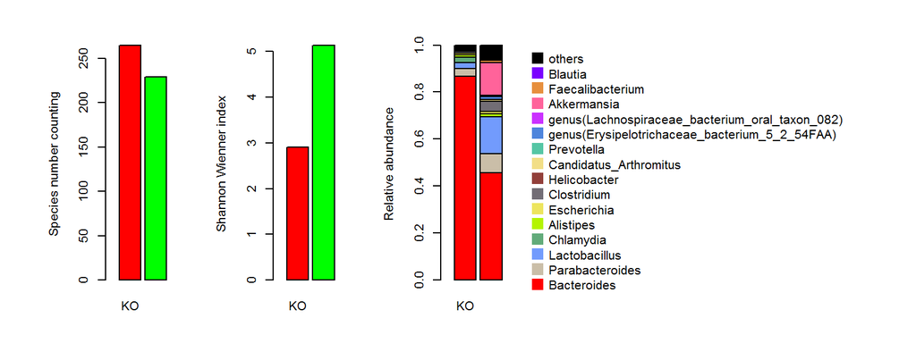

```r
opar <- par(no.readonly=TRUE)
###Set the layout
layout(t(as.matrix(c(1,2,3,4))),widths = c(6,6,6,11))
par(oma = c(2,3,1,4), mar = c(2, 4, 2, 2))

###Species number count bar plot-----------------------------------------------------------

### species composition  use data absolute
data <- profiling_species_absolute
data <- data[,c("KO_0w", "WT_0w")]
colnames(data) <- c("KO", "WT")
###Abundance of species filter
data[data <= 1e-6] <- 0
###Remove the sum of each row ==0
data <- data[which(rowSums(data) > 0),]
###Data were normalized
data <- apply(data, 2, uniform)
###Species counting
sumvect <- apply(data, 2, numberof)
barplot(sumvect,col=c("red", "green"), ylab = "Species number counting", xlim = c(-0.3, 3))

# shannon plot----------------------------------------------------------------------

###Calculate shannon value
numvect <- apply(data, 2, shannon)
barplot(numvect,col=c("red", "green"), ylab = "Shannon Wienner index", xlim = c(-0.3, 3))

# genus composition plot------------------------------------------------------------------

### genus composition  data
data <- profile_genus
data = data[,c("KO_0w", "WT_0w")]
colnames(data) = c("KO", "WT")
###Remove the sum of each row ==0
temp <- rm_sort(data)
data <- temp[[1]]
table <- temp[[2]]
top <- 12
###Statistics of the top and other value
tabletmp <- apply(table, 2, merge_low_abundance, vector_name = rownames(table))
rowsum <- apply(tabletmp, 1, sum)
tabletmp <- tabletmp[which(rowsum != 0),]
table2 <- table <- as.data.frame(tabletmp[1:(nrow(tabletmp) -1),])
###order table
table <- table[do.call(order, -table2),]
table <- as.matrix(rbind(table, others = tabletmp["others",]))

barplot(table, col = colfunc(nrow(table)), ylab = "Relative abundance", xlim = c(-0.3, 3))
plot(0, type = "n", xaxt = "n", yaxt = "n", bty ="n", xlab = "", ylab = "",
     xlim = c(-1, 1), ylim = c(-1, 1))
legend(-1.9, 1.1, pch = 15, col = rev(colfunc(nrow(table))), legend = rev(rownames(table)),
       bty = "n", pt.cex = 2, ncol = 1, xpd = NA)
```

## Fig3-B

- `a`: Total OTU sequences taxonomically assigned to bacterial phyla from fecal metagenomes of WT or Il-17a-/- mice at weeks 0, 14 and 27. Each bar represents the mean of the microbiota composition from five to eight mice

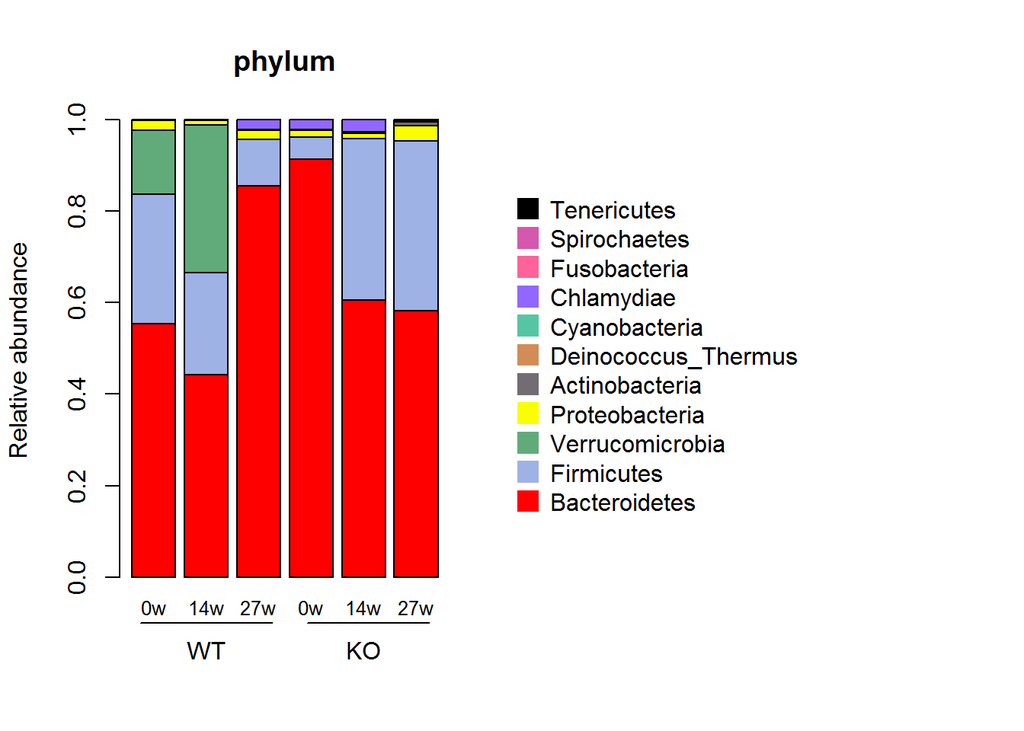

```r
par(opar)
###Set the layout
par(mfrow = c(1,2), xpd = NA)
### phylum level composition
data <- profile_phylum
data <- data[, c("WT_0w", "WT_14w", "WT_27w", "KO_0w", "KO_14w", "KO_27w")]
temp <- rm_sort(data)
data <- temp[[1]]
table <- temp[[2]]
spa <- 0.2
width <- 1
colornumber <- 20
top <- 12
blacked <- T
if(nrow(table) > top+1){
  merge_low_abundance <- function(x, vector_name){
    others_ind <- order(-x)[-(1:top)]
    others <- sum(x[others_ind])
    x[others_ind] <- 0
    x <- c(x, others = others)
    x
  }
  tabletmp <- apply(table, 2, merge_low_abundance, vector_name = rownames(table))
  rowsum <- apply(tabletmp, 1, sum)
  tabletmp <- tabletmp[which(rowsum != 0),]
  table2 <- table <- as.data.frame(tabletmp[1:(nrow(tabletmp) -1),])
  table <- table[do.call(order, -table2),]
  table <- as.matrix(rbind(table, others = tabletmp["others",]))
}else{
  blacked <- F
  table <- table[do.call(order, -as.data.frame(table)),]
  table <- as.matrix(table)
  top <- nrow(table)
}

barplot(table, col = colfunc(nrow(table)), ylab = "Relative abundance", xaxt = "n", main = "phylum")
text(seq(from = 0.7,length = ncol(table), by=spa + width),par("usr")[3] - 0.01,
     labels=c("0w", "14w", "27w", "0w", "14w", "27w"),xpd=T,font=1,cex=0.8, pos = 1)
segments(0.4, -0.1, 3.4, -0.1)
segments(4.2, -0.1, 7, -0.1)
text(c(1.9, 5.5),par("usr")[3] - 0.1,labels=c("WT", "KO"),xpd=T,font=1,cex=1, pos = 1)
plot(0, type = "n", xaxt = "n", yaxt = "n", bty ="n", xlab = "", ylab = "",
     xlim = c(-1, 1), ylim = c(-1, 1))
legend(-1.9, 0.8, pch = 15, col = rev(colfunc(nrow(table))), legend = rev(rownames(table)),
       bty = "n", pt.cex = 2, ncol = 1, xpd = NA)
```

## Fig3-C

- `a`: Venn diagram of WT and KO (Il-17-/-) mice in 0w, 14w and 27w after HFD feeding

```r
library("grid")
library("VennDiagram")
```

```r
### species composition  use data absolute
data <- profiling_species
data <- apply(data, 2, uniform)
data <- as.data.frame(data)
###the sample list,KO_0w VS WT_0w,KO_14w Vs WT_14w,KO_27w vs WT_27w
samplelist <- c("KO_0w", "WT_0w","KO_14w", "WT_14w","KO_27w", "WT_27w")
for(i in 1:(length(samplelist)/2)*2-1){
  samples <- samplelist[i:(i+1)]
  numberlist <- as.list(data[, samples])
  rnames <- rownames(data)
  modifylist <-function(list){
    numberlistnames <- names(list)
    newlist <- list()
    for (i in numberlistnames){
      newlist[[i]] <- rnames[which(list[[i]] > 0)]
    }
    newlist
  }
  newlist <- modifylist(numberlist)
  venn.diagram(newlist, imagetype="png",category.names = names(newlist), fill = c("red", "blue"),
               paste(c(samples[1], "_", samples[2], ".png"), collapse = ""), cat.dist = 0.08,
               margin = 0.2, cat.cex = 2, cex = 2, main.cex = 1.6, cat.pos = c(-60, 60),
               main = paste("\n", "\n", "\n", "\n", "\n", paste(samples, collapse = " vs "), sep = ""))

}
```

## A. fig3-C

- `b`: (left) New appearing species in 14w compared with 0w

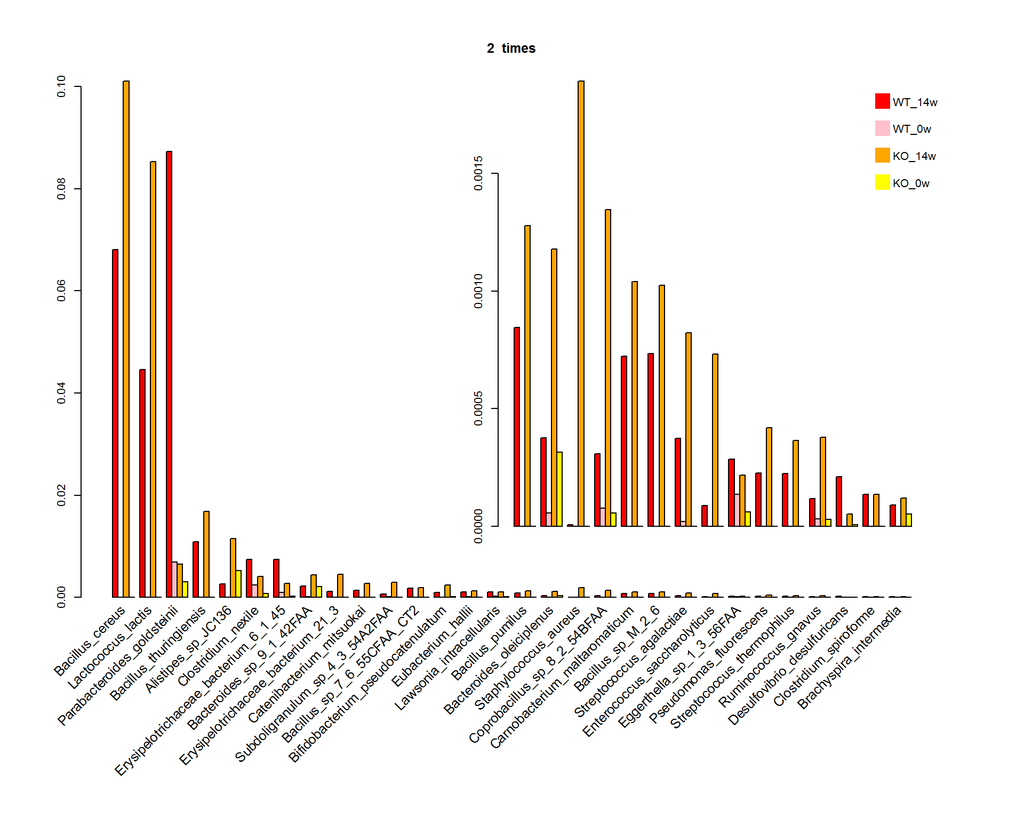

```r
par(opar)
data <- profiling_species_absolute
###Abundance of species filter
data[data <= 1e-6] <- 0
###Data were normalized
data <- apply(data, 2, uniform)
data <- data[,c("WT_14w", "WT_0w", "KO_14w", "KO_0w")]
###set top
tops <- 30
###set drawing parameters
spa <- 1
width <- 1
###set layout
par(mar=c(15, 5, 5, 5), oma = c(1,1,1,1))
layout(rbind(c(1,2,1),c(1,2,1),c(1,1,1)), width = c(6.8, 9.2, 0.25), height = c(2, 2, 0.4))
###set times
times <- 2
wtappear <- data[,"WT_14w"] > times * data[, "WT_0w"]
koappear <- data[,"KO_14w"] > times * data[, "KO_0w"]
appeartimes2 <- data[wtappear & koappear,]
rowsums <- rowSums(appeartimes2)
appeartimes2 <- appeartimes2[order(-rowsums),]
###drawing barplot
barplot(t(appeartimes2[1:tops,]), beside = T, main = paste(times, " times", sep = " "),
        xaxt = "n", col = c("red", "pink", "orange", "yellow"))
text(seq(from = 4 * width,length = nrow(appeartimes2[1:tops,]), by=4 * spa + width),
     par("usr")[3] - 0.001,srt=45,adj=0,labels=rownames(appeartimes2[1:tops,]),
     xpd=T,font=1,cex=1.2, pos = 2)
legend("topright", legend = colnames(appeartimes2), pch = 15,
       col = c("red", "pink", "orange", "yellow"),
       bty = "n", y.intersp = 2, pt.cex = 3)
barplot(t(appeartimes2[16:tops,]), beside = T, xaxt = "n",
        col = c("red", "pink", "orange", "yellow"))
```

```r
###end
```

## Fig3-C

- `b`: (right) Increasing species in 27w compared with 14w

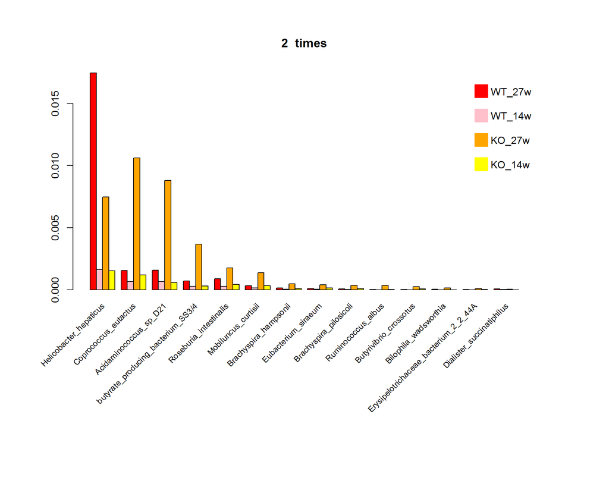

```r
par(opar)
data <- profiling_species_absolute
###Abundance of species filter
data[data <= 1e-6] <- 0
###Data were normalized
data <- apply(data, 2, uniform)
data <- data[,c("WT_27w", "WT_14w", "KO_27w", "KO_14w")]
wt27 <- (data[,"WT_27w"] > 0)
wt14 <- (data[,"WT_14w"] > 0)
ko27 <- (data[,"KO_27w"] > 0)
ko14 <- (data[,"KO_14w"] > 0)
data <- data[wt27 & wt14 & ko27 & ko14, ]
###set top
tops <- 30
###set drawing parameters
spa <- 1
width <- 1
###set time
times <- 2
wtappear <- data[,"WT_27w"] > times * data[, "WT_14w"]
koappear <- data[,"KO_27w"] > times * data[, "KO_14w"]
appeartimes2 <- data[wtappear & koappear,]
rowsums <- rowSums(appeartimes2)
appeartimes2 <- appeartimes2[order(-rowsums),]
###set layout
par(mar=c(15, 5, 5, 5), oma = c(1,1,1,1))

barplot(t(appeartimes2), beside = T, main = paste(times, " times", sep = " "),
        xaxt = "n", col = c("red", "pink", "orange", "yellow"))
text(seq(from = 4 * width,length = nrow(appeartimes2),
         by=4 * spa + width),par("usr")[3] - 0.001,srt=45,
     adj=0,labels=rownames(appeartimes2),xpd=T,font=1,cex=0.8, pos = 2)
legend("topright", legend = colnames(appeartimes2), pch = 15, col = c("red", "pink", "orange", "yellow"),
       bty = "n", y.intersp = 2, pt.cex = 3)
```

## Fig3-D

- `right`: Right: tendency of species proportion

```r
par(opar)
data <- profiling_species_absolute
###Abundance of species filter
data[data <= 1e-6] <- 0
###Data were normalized
data <- apply(data, 2, uniform)
###Do filter conditions with max_data
max_data <- apply(data, 1, max)
data <- data[which(max_data >= 1e-3),]
###To obtain rownames
rnames <- rownames(data)
prefix <- "[KW].*_[0-9]*w"
###TO obtain samplenames
samplenames <- colnames(data)[grep(prefix, colnames(data))]
subtable <- data[,samplenames]

check_core_species <- function(vect, number){
  if(length(which(vect > 0)) >= number){
    T
  }else{
    F
  }
}

core_vect <- apply(subtable, 1, check_core_species, number = ncol(subtable))
kowt <- subtable[core_vect,]
subdata <- data[rownames(kowt),grep("_[0-9]+w", colnames(data))]
###Statistical correlation
cc <- cor(t(subdata), method = "spearman")
###merge species as long as they are correlated.
cc <- abs(cc)
rho <- 0.85
d <-  1-cc
d <- as.dist(d)
hc <- hclust(d, "complete")
###plot(hc);abline(rho,0, col="red")
tt <- cutree(hc,h=1-rho)

color_vect <- colfunc(nrow(table))

###putout 02.species.relation
write.table("representer\tspecies", "02_species.relation", quote = F, col.names = F, row.names = F)
relation <- list()
finalnames <- vector()
for (rownumber in range(tt)[1]:range(tt)[2]){
  row_names <- names(tt[which(tt == rownumber)])
  if(length(row_names) > 1){
    newmat <- subdata[row_names,]
    newmatsum <- apply(newmat, 1, sum)
    finalnames <- c(finalnames, row_names[which(newmatsum == max(newmatsum))])
    relation[[ row_names[which(newmatsum == max(newmatsum))]]] <- row_names[-which(newmatsum == max(newmatsum))]
    write.table(paste(row_names, collapse = "\t"), "02_species.relation", quote = F, col.names = F,
                row.names = F, append = T)
  }else{
    finalnames <- c(finalnames, row_names)
    relation[[ row_names]] <- NA
    write.table(row_names, "02_species.relation", quote = F, col.names = F, row.names = F, append = T)
  }
}
finalmat <- subdata[finalnames,]

prefix <- "[KW].*_[0-9]*w"
samplenames <- colnames(finalmat)[grep(prefix, colnames(finalmat))]
kowt <- finalmat[,samplenames]


###load data
ko_prefix <- "KO"
ko_names <- colnames(kowt)[grep(ko_prefix, colnames(kowt))]
ko <- kowt[, ko_names]
wt_prefix <- "WT"
wt_names <- colnames(kowt)[grep(wt_prefix, colnames(kowt))]
wt <- kowt[, wt_names]
cutoff <- 3
check_variation <- function(vect, cutoff){
  max_value <- max(vect)
  min_value <- min(vect)

  if(max_value < 0){
    F
  }else if(min_value == 0){
    T
  }else if(max_value / min_value >= cutoff) {
    T
  }else{
    F
  }
}

ko_names <- rownames(kowt)[apply(ko, 1, check_variation, cutoff = cutoff)]
wt_names <- rownames(kowt)[apply(wt, 1, check_variation, cutoff = cutoff)]
table <- kowt[unique(c(ko_names, wt_names)),]

test <- cor(t(table[,1:3]), t(table[,4:6]), method = "spearman")
diag_names <- names(diag(test)[which(diag(test) == -1)])

write.table("representer\tspecies", "02_species.relation", quote = F, col.names = F, row.names = F)
for (name in diag_names){
  if(is.na(relation[[name]][1])){
    write.table(name, "02_species.relation", quote = F, col.names = F, row.names = F, append = T)
  }else{
    write.table(paste(c(name, relation[[name]]), collapse = "\t"), "02_species.relation", quote = F,
                col.names = F, row.names = F, append = T)
  }
}
table <- table[diag_names,]

###set layout
layout(rbind(c(1,2),c(3,4),c(5,5)), width = c(3, 3), height = c(3, 3, 2))
###draw plot a
plot(0, xlim = c(0, (ncol(table) + 2)), ylim = c(0, 0.05), bty = "n", type = "n", xlab = "",
     ylab = "", xaxt = "n",main = "a")
axis(1, at = 1:(ncol(table) + 2), labels = rep("", (ncol(table) + 2)))
text(seq(from = 0.9, length = (ncol(table) + 2), by = 1),par("usr")[3] - 0.008,srt=90,adj=0,
     labels=c(colnames(table), "NOR_14w", "NOR_27w"),xpd=T,font=1,cex=0.9, pos = 1)
abline(v = 1:(ncol(table) +2), col = "gray")
rownumber <- 0
speciesnames <- c()
colornames <- c()
for ( i in 1:nrow(table)){
  if(table[i,1] < table[i,2] && table[i,2] < table[i,3]){
    rownumber <- rownumber + 1
    speciesnames <- c(speciesnames, rownames(table)[i])
    colornames <- c(colornames, palette[rownumber])
    lines(1:3, as.vector(table[i,1:3]) , col = palette[rownumber], lwd = 2)
    lines(4:6, as.vector(table[i,4:6]) , col = palette[rownumber], lwd = 2)
    lines((ncol(table) + 1):(ncol(table) + 2), as.vector(data[rownames(table)[i], c("NOR_14w", "NOR_27w")]),
          col = palette[rownumber], lwd = 2)
  }
}
###draw plot b
plot(0, xlim = c(0, (ncol(table) + 2)), ylim = c(0, 1), bty = "n", type = "n", xlab = "", ylab = "",
     xaxt = "n", main = "b")
axis(1, at = 1:(ncol(table) + 2), labels = rep("", (ncol(table) + 2)))
text(seq(from = 0.9, length = (ncol(table) + 2), by = 1),par("usr")[3] - 0.17,srt=90,adj=0,
     labels=c(colnames(table), "NOR_14w", "NOR_27w"),xpd=T,font=1,cex=0.9, pos = 1)
abline(v = 1:(ncol(table) +2), col = "gray")
for ( i in 1:nrow(table)){
  if(table[i,1] > table[i,2] && table[i,2] > table[i,3]){
    rownumber <- rownumber + 1
    speciesnames <- c(speciesnames, rownames(table)[i])
    colornames <- c(colornames, palette[rownumber])
    lines(1:3, as.vector(table[i,1:3]) , col = palette[rownumber], lwd = 2)
    lines(4:6, as.vector(table[i,4:6]) , col = palette[rownumber], lwd = 2)
    lines((ncol(table) + 1):(ncol(table) + 2), as.vector(data[rownames(table)[i],c("NOR_14w", "NOR_27w")]),
          col = palette[rownumber], lwd = 2)
  }
}


###draw plot c
plot(0, xlim = c(0, (ncol(table) + 2)), ylim = c(0, 0.07), bty = "n", type = "n", xlab = "", ylab = "",
     xaxt = "n", main = "c")
axis(1, at = 1:(ncol(table) + 2), labels = rep("", (ncol(table) + 2)))
text(seq(from = 0.9, length = (ncol(table) + 2), by = 1),par("usr")[3] - 0.011,srt=90,adj=0,
     labels=c(colnames(table),"NOR_14w", "NOR_27w"),xpd=T,font=1,cex=0.9, pos = 1)
abline(v = 1:(ncol(table) +2), col = "gray")
for ( i in 1:nrow(table)){
  if(table[i,1] > table[i,2] && table[i,2] < table[i,3]){
    rownumber <- rownumber + 1
    speciesnames <- c(speciesnames, rownames(table)[i])
    colornames <- c(colornames, palette[rownumber])
    lines(1:3, as.vector(table[i,1:3]) , col = palette[rownumber], lwd = 2)
    lines(4:6, as.vector(table[i,4:6]) , col = palette[rownumber], lwd = 2)
    lines((ncol(table) + 1):(ncol(table) + 2), as.vector(data[rownames(table)[i], c("NOR_14w", "NOR_27w")]),
          col = palette[rownumber], lwd = 2)
  }
}

###draw plot d
plot(0, xlim = c(0, (ncol(table) + 2)), ylim = c(0, 0.03), bty = "n", type = "n", xlab = "", ylab = "",
     xaxt = "n", main = "d")
axis(1, at = 1:(ncol(table) + 2), labels = rep("", (ncol(table) + 2)))
text(seq(from = 0.9, length = (ncol(table) + 2), by = 1),par("usr")[3] - 0.005,srt=90,adj=0,
     labels=c(colnames(table), "NOR_14w", "NOR_27w"),xpd=T,font=1,cex=0.9, pos = 1)
abline(v = 1:(ncol(table) +2), col = "gray")
for ( i in 1:nrow(table)){
  if(table[i,1] < table[i,2] && table[i,2] > table[i,3]){
    rownumber <- rownumber + 1
    speciesnames <- c(speciesnames, rownames(table)[i])
    colornames <- c(colornames, palette[rownumber])
    lines(1:3, as.vector(table[i,1:3]) , col = palette[rownumber], lwd = 2)
    lines(4:6, as.vector(table[i,4:6]) , col = palette[rownumber], lwd = 2)
    lines((ncol(table) + 1):(ncol(table) + 2), as.vector(data[rownames(table)[i], c("NOR_14w", "NOR_27w")]),
          col = palette[rownumber], lwd = 2)
  }
}
par(mar = c(0,0,0,0))
plot(0, xlim = c(0, (ncol(table) + 2)), ylim = c(0, 0.03), bty = "n", type = "n", xlab = "", ylab = "",
     xaxt = "n", yaxt = "n")
names(speciesnames) <- colornames
speciesnames <- sort(speciesnames)
legend("top", legend = speciesnames, col = names(speciesnames), lwd = 2, bty = "n", ncol = 2)
```

[output not shown]

# Fig.4 Co-house of WT and Il-17a-/- mice corrects WT mice disorders induced by

```
HFD through regulating gut microbiota
```

## Fig 4-H

- Unweighted UniFrac-based PCoA plot based on all OTUs

```r
par(opar)
library(cluster)
library(MASS)
library(clusterSim)
library(ade4)
data <- profiling_species
###Statistical Frac dist
data.dist <- dist.Frac(data)
###Statistical pam cluster
data.cluster <- pam.clustering(data.dist, k=3)
obs.silhouette <- mean(silhouette(data.cluster, data.dist)[,3])
###silhouette coefficient ; The greater the value of classification, the better
cat(obs.silhouette) #0.1899451
```

```
## 0.1236197
```

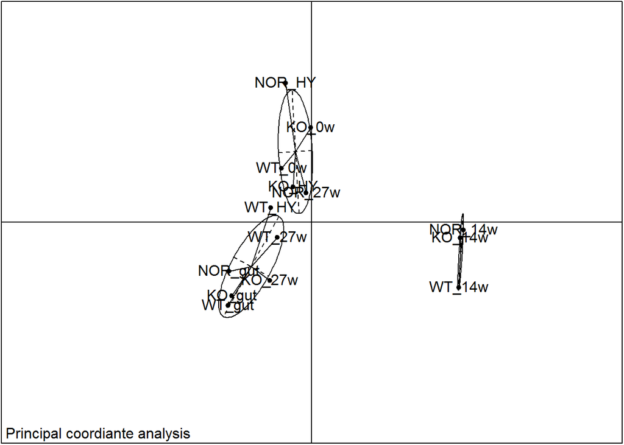

```r
###statistical pcoa
obs.pcoa <- dudi.pco(data.dist, scannf=F, nf=3)
###plot pcoa
s.class(obs.pcoa$li, fac=as.factor(data.cluster), grid=F,sub="Principal coordiante analysis",
        xlim = c(-0.4, 0.4),ylim = c(-0.4, 0.4), clabel = 0)
text(obs.pcoa$li[,1], obs.pcoa$li[,2], rownames(obs.pcoa$li))
```

## Fig 4-I

- The PCoA analysis focus on grouping sampled fecal communities with respect to diet (NCD, HFD) and time of stool sampling (weeks 0, 14, 27, or HY) using principal components.

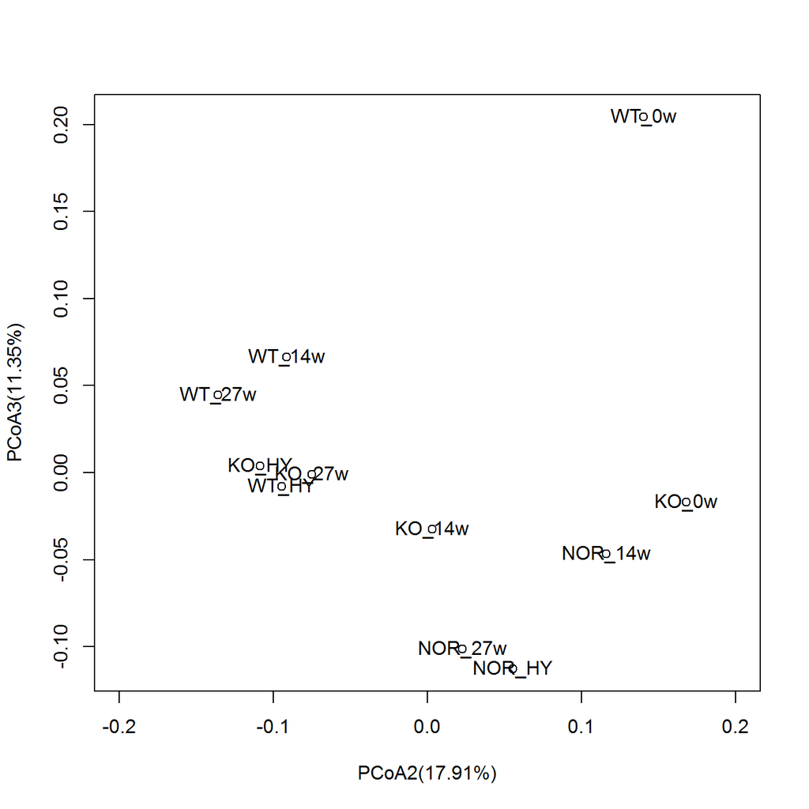

```r
par(opar)
###Load data
data <- profiling_species_absolute
data <- as.matrix(data[,c("KO_0w", "KO_27w", "KO_14w",  "WT_0w", "WT_14w", "WT_27w",
                          "NOR_27w","NOR_14w","WT_HY", "KO_HY", "NOR_HY")])
###Abundance of species filter
data[data <= 1e-6] <- 0
###Statistical Frac dist
data.dist=dist.Frac(data)
###Statistical PCOA
obs.pcoa=dudi.pco(data.dist, scannf=F, nf=10)
rat <- obs.pcoa$eig/sum(obs.pcoa$eig) * 100
plot(obs.pcoa$li[,2], obs.pcoa$li[,3], xlab = paste("PCoA2(", round(rat[2], digit = 2), "%)", sep = ""),
     ylab = paste("PCoA3(", round(rat[3], digit = 2), "%)", sep = ""), xlim = c(-0.2, 0.2))
text(obs.pcoa$li[,2], obs.pcoa$li[,3], rownames(obs.pcoa$li))
```

## Fig-4J

```r
par(opar)
###set layout
par(mfrow = c(1,2), xpd = NA)
profile <- profiling_species
profile <- profile[, c("WT_27w", "KO_27w", "WT_HY", "KO_HY")]
###remvoe the sum of each row ==0
profile <- profile[which(rowSums(profile) > 0),]
rowsums <- rowSums(profile)
table <- as.matrix(profile[order(-rowsums), ])
###Set drawing parameters
spa <- 0.2
width <- 1
colornumber <- 20
top <- 12

blacked <- T
if(nrow(table) > top+1){
  merge_low_abundance <- function(x, vector_name){
    others_ind <- order(-x)[-(1:top)]
    others <- sum(x[others_ind])
    x[others_ind] <- 0
    x <- c(x, others = others)
    x
  }
  tabletmp <- apply(table, 2, merge_low_abundance, vector_name = rownames(table))
  rowsum <- apply(tabletmp, 1, sum)
  tabletmp <- tabletmp[which(rowsum != 0),]
  table <- as.data.frame(tabletmp[1:(nrow(tabletmp) -1),])
  table2 <- as.data.frame(table)
  table <- table[do.call(order, -table2),]
  table <- as.matrix(rbind(table, others = tabletmp["others",]))
}else{
  blacked <- F
  table <- table[do.call(order, -as.data.frame(table)),]
  table <- as.matrix(table)
  top <- nrow(table)
}
###draw barplot
barplot(table, col = colfunc(nrow(table)), ylab = "Relative abundance", xaxt = "n", main = "Genus")
text(seq(from = 0.7,length = ncol(table), by=spa + width),par("usr")[3] - 0.01,
     labels=c("WT", "KO", "WT", "KO"),xpd=T,font=1,cex=0.8, pos = 1)
segments(0.4, -0.1, 2.2, -0.1)
segments(2.8, -0.1, 4.6, -0.1)
text(c(1.3, 3.7),par("usr")[3] - 0.1,labels=c("WT", "KO"),xpd=T,font=1,cex=1, pos = 1)
plot(0, type = "n", xaxt = "n", yaxt = "n", bty ="n", xlab = "", ylab = "",
     xlim = c(-1, 1), ylim = c(-1, 1))
legend(-1.9, 0.8, pch = 15, col = rev(colfunc(nrow(table))), legend = rev(rownames(table)),
       bty = "n", pt.cex = 2, ncol = 1, xpd = NA)
```

[output not shown]

# Fig.5 The network of top 30 species

## Fig5-A

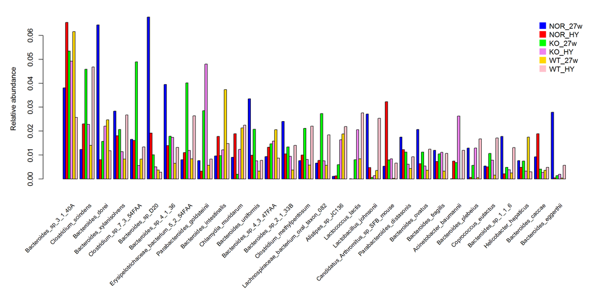

```r
par(opar)
###Load data
data <- profiling_species_absolute
###Abundance of species filter
data[data <= 1e-6] <- 0
data <- apply(data, 2, uniform)
vect <- c("NOR_27w", "NOR_HY", "KO_27w", "KO_HY", "WT_27w", "WT_HY")
tops <- 30
###set drawing parameters
width <- 1
spa <- 1
cols=c("blue", "red", "green", "violet", "gold", "pink")
data2 <- data[, vect]
sumvect <- apply(data2, 1, sum)
data3 <- data2[order(-sumvect),]
data3 <- data3[-1,]
###set layout
par(mar = c(14,5,2,2))
###draw barplot
barplot(t(data3[1:tops,]), beside = T, col = cols[1:length(vect)],xaxt = "n",
        ylab = "Relative abundance")
text(seq(from = (length(vect) + 1) * width,length = tops, by= spa + length(vect) * width),
     (par("usr")[3] - 0.01),srt=45,adj=1,labels=rownames(data3)[1:tops],xpd=T,font=1,cex=0.8, pos = 2)
legend("topright", legend = colnames(data3), pch = 15,
       col = cols[1:length(vect)], pt.cex = 2, bty = "n")
```

```r
###end
```

# Fig.6 Upregulated or downregulated modules in HFD-14w vs 0w, 27w vs 14w and 874 27w vs 0w We use the other drawing software.**